# CREscendo Tutorial: Analysis of 10X Genomics Adult Mouse Cortex ATAC Chromium v2

# Installation

To install the `CREscendo` package, you can use the code.

```r
devtools::install_github("ChenMengjie/CREscendo")
```

Then load the following libraries used in this tutorial:

```r
library(Signac)
library(Seurat)
library(EnsDb.Hsapiens.v75)
library(TxDb.Hsapiens.UCSC.hg38.knownGene)
library(CREscendo)
library(ggrepel)
library(tictoc)
```

# Dataset: Mouse cortex, ATAC v2, Chromium X

We downloaded the mouse cortex scATAC-seq dataset, which includes peak files and fragment files, from [10x Genomics](https://www.10xgenomics.com/datasets/8k-adult-mouse-cortex-cells-atac-v2-chromium-x-2-standard). The dataset initially contained 8,067 nuclei. We conducted quality control and cell type annotations using [Signac](https://stuartlab.org/signac/) as below.

```r
counts <- Read10X_h5("8k_mouse_cortex_ATACv2_nextgem_Chromium_X_filtered_peak_bc_matrix.h5")
metadata <- read.csv(
  file = "8k_mouse_cortex_ATACv2_nextgem_Chromium_X_singlecell.csv",
  header = TRUE,
  row.names = 1
)

brain_assay <- CreateChromatinAssay(
  counts = counts,
  sep = c(":", "-"),
  genome = "mm10",
  fragments = '8k_mouse_cortex_ATACv2_nextgem_Chromium_X_fragments.tsv.gz',
  min.cells = 1
)

brain <- CreateSeuratObject(
  counts = brain_assay,
  assay = 'peaks',
  project = 'ATAC',
  meta.data = metadata
)

# extract gene annotations from EnsDb
annotations <- GetGRangesFromEnsDb(ensdb = EnsDb.Mmusculus.v79)

seqlevels(annotations) <- paste0('chr', seqlevels(annotations))
genome(annotations) <- "mm10"

# add the gene information to the object
Annotation(brain) <- annotations


brain <- NucleosomeSignal(object = brain)

brain$nucleosome_group <- ifelse(brain$nucleosome_signal > 4, 'NS > 4', 'NS < 4')
FragmentHistogram(object = brain, group.by = 'nucleosome_group', region = 'chr1-1-10000000')

brain <- TSSEnrichment(brain, fast = FALSE)


brain$high.tss <- ifelse(brain$TSS.enrichment > 2, 'High', 'Low')
TSSPlot(brain, group.by = 'high.tss') + NoLegend()

brain$pct_reads_in_peaks <- brain$peak_region_fragments / brain$passed_filters * 100
brain$blacklist_ratio <- brain$blacklist_region_fragments / brain$peak_region_fragments

VlnPlot(
  object = brain,
  features = c('pct_reads_in_peaks', 'peak_region_fragments',
               'TSS.enrichment', 'blacklist_ratio', 'nucleosome_signal'),
  pt.size = 0.1,
  ncol = 5
)

brain <- subset(
  x = brain,
  subset = peak_region_fragments > 3000 &
    peak_region_fragments < 100000 &
    pct_reads_in_peaks > 40 &
    blacklist_ratio < 0.025 &
    nucleosome_signal < 4 &
    TSS.enrichment > 2
)
brain



brain <- RunTFIDF(brain)
brain <- FindTopFeatures(brain, min.cutoff = 'q0')
brain <- RunSVD(object = brain)
DepthCor(brain)


brain <- RunUMAP(
  object = brain,
  reduction = 'lsi',
  dims = 2:30
)
brain <- FindNeighbors(
  object = brain,
  reduction = 'lsi',
  dims = 2:30
)
brain <- FindClusters(
  object = brain,
  algorithm = 3,
  resolution = 1.2,
  verbose = FALSE
)

DimPlot(object = brain, label = TRUE) + NoLegend()



# compute gene activities
gene.activities <- GeneActivity(brain)

# add the gene activity matrix to the Seurat object as a new assay
brain[['RNA']] <- CreateAssayObject(counts = gene.activities)
brain <- NormalizeData(
  object = brain,
  assay = 'RNA',
  normalization.method = 'LogNormalize',
  scale.factor = median(brain$nCount_RNA)
)

DefaultAssay(brain) <- 'RNA'
FeaturePlot(
  object = brain,
  features = c('Sst','Pvalb',"Gad2","Neurod6","Rorb","Syt6"),
  pt.size = 0.1,
  max.cutoff = 'q95',
  ncol = 3
)


all.width <- brain@assays$peaks@ranges@ranges@width

allen_rna <- readRDS("allen_brain.rds")
allen_rna <- UpdateSeuratObject(allen_rna)
allen_rna <- FindVariableFeatures(
  object = allen_rna,
  nfeatures = 5000
)

transfer.anchors <- FindTransferAnchors(
  reference = allen_rna,
  query = brain,
  reduction = 'cca',
  dims = 1:30
)

predicted.labels <- TransferData(
  anchorset = transfer.anchors,
  refdata = allen_rna$subclass,
  weight.reduction = brain[['lsi']],
  dims = 2:30
)

brain <- AddMetaData(object = brain, metadata = predicted.labels)
plot1 <- DimPlot(allen_rna, group.by = 'subclass', label = TRUE, repel = TRUE) + NoLegend() + ggtitle('scRNA-seq')
plot2 <- DimPlot(brain, group.by = 'predicted.id', label = TRUE, repel = TRUE) + NoLegend() + ggtitle('scATAC-seq')
plot1 + plot2

#switch back to working with peaks instead of gene activities
DefaultAssay(brain) <- 'peaks'
Idents(brain) <- "predicted.id"
```

Or you can start with pre-processed object, which can be downloaded from [Pre-processed dataset 3](https://drive.google.com/file/d/1N34NZYH1LfDs4RPE9y_FGDMc7Cx2cMVj/view?usp=sharing).

```r
load("/path/to/brain_8k-adult-mouse-cortex_annotated_after_QC.rda")
brain
peaks.gr <- granges(brain@assays$peaks)
peaks.gr <- peaks.gr[grep("chr", seqnames(peaks.gr))]
peaks.gr
```

We have implemented functions to load the CREs from the ENCODE SCREEN V3 directly.

```r
CRE_gr <- CREscendo:::load_CRE_annotations(genome = "mm10")
CRE_gr
```

```
## GRanges object with 368121 ranges and 3 metadata columns:
##            seqnames              ranges strand |          ID1          ID2
##               <Rle>           <IRanges>  <Rle> |  <character>  <character>
##        [1]     chr1     3012681-3012836      + | EM10D1036230 EM10E0932225
##        [2]     chr1     3119617-3119911      + | EM10D1036249 EM10E0431203
##        [3]     chr1     3119914-3120119      + | EM10D2262517 EM10E0932226
##        [4]     chr1     3120346-3120662      + | EM10D1036251 EM10E0431205
##        [5]     chr1     3445885-3446198      + | EM10D1036337 EM10E0431211
##        ...      ...                 ...    ... .          ...          ...
##   [368117]     chrX 166516781-166517123      + | EM10D2261053 EM10E1234933
##   [368118]     chrX 166539724-166540065      + | EM10D2261067 EM10E1234936
##   [368119]     chrX 166895215-166895561      + | EM10D2261208 EM10E1234954
##   [368120]     chrX 169861337-169861669      + | EM10D2994601 EM10E1235078
##   [368121]     chrX 169883413-169883757      + | EM10D2994616 EM10E1235088
##                            type
##                     <character>
##        [1] CTCF-only,CTCF-bound
##        [2]                 dELS
##        [3]                 dELS
##        [4]                 dELS
##        [5]                 pELS
##        ...                  ...
##   [368117]                 dELS
##   [368118]                 dELS
##   [368119]                 dELS
##   [368120]                 dELS
##   [368121]                 dELS
##   -------
##   seqinfo: 21 sequences from an unspecified genome; no seqlengths
```

You can also prepare your own annotations file from other sources like the following:

```r
anno_CREs <- read.delim("/path/to/mm10-cCREs.bed", header = F)
CRE_gr <- GRanges(ranges=IRanges(start=anno_CREs[, 2], end=anno_CREs[, 3]),
                  seqnames=anno_CREs[, 1],
                  strand=rep("+", nrow(anno_CREs)), ID1 = anno_CREs[, 4], ID2 = anno_CREs[, 5],
                  type = anno_CREs[, 6])
CRE_gr
```

We can compare the peak sizes and the CRE sizes.

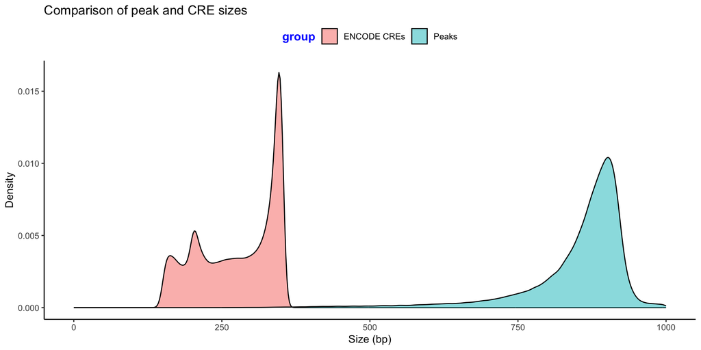

```r
peak_width <- width(peaks.gr)
CRE_width <- width(CRE_gr)
data <- data.frame(
  values = c(CRE_width, peak_width),
  group = c(rep("ENCODE CREs", length(CRE_width)),
            rep("Peaks", length(peak_width)))
)

####
pg <- ggplot(data, aes(x = values, fill = group)) +
  geom_density(alpha = 0.5, adjust = 1.2) +
  theme_classic() + xlim(0, 1000)+
  labs(title = "Comparison of peak and CRE sizes", x = "Size (bp)", y = "Density") +
  theme(legend.title = element_text(color = "blue", size = 12, face = "bold"),
        legend.position = "top")
pg
```

## Creating a CREscendo Test Data Object

In the CREscendo test, Tn5 cleavage frequencies are used as the input. However, this information is not readily available in the peak file alone. To obtain Tn5 cleavage data, we need to screen the fragment files. Given that these fragment files are typically quite large, we opt for the Tabix-indexed file format. Tabix files are compressed and indexed, allowing for efficient data retrieval.

The `PrepareCREscendoObject` function serves as our tool for constructing a CREscendo object. This involves several steps:

1. **Processing and annotating Genomic Peaks**: Initially, we process genomic peaks, which are typically stored in a GenomicRanges object (`peaks_gr`).
2. **Associating Peaks with CREs**: We associate these peaks with cis-regulatory elements (CREs), thereby establishing their regulatory context.
3. **Compiling Cleavage Site Counts**: The core aspect of the process involves compiling counts of cleavage sites. This requires accessing the Tabix-indexed file (`tabix_file`) containing relevant fragment data.

The `PrepareCREscendoObject` function expects the following inputs:

- `peaks_gr`: GenomicRanges object containing genomic peak locations.
- `tabix_file`: Path to a Tabix-indexed file containing fragments relevant to the peaks.
- `cell_annotation`: Data frame containing cell annotations with columns for cell name and cell type.
- `celltype_list` (Optional): A vector of cell types to include in the analysis. If NULL, all unique cell types from `cell_annotation` will be used.
- `CRE_gr`: GenomicRanges object for cis-regulatory elements.
- `tssRegion`: Numeric vector of length 2 specifying the region around transcription start sites to consider for annotation (defaults to c(-1000, 1000)).
- `TxDb`: A TxDb object containing transcript annotations.
- `annoDb`: Character string, the Bioconductor annotation package for organism-specific data. Default is “org.Hs.eg.db” for human.
- `multiCREs`: Logical value indicating whether to include peaks with multiple CREs (TRUE) or all peaks (FALSE). Default is TRUE.

This function streamlines the process, allowing for efficient preparation and construction of the necessary data object for the CREscendo test.

We applied `PrepareCREscendoObject` to extract Tn5 cleavage sites for selected cell types this dataset.

```r
cells <- colnames(x = brain@assays$peaks)
cell_type_list <- c("L2/3 IT", "Oligo", "L4", "Astro")
cell_annotation <- data.frame(celltype = brain@active.ident[brain@active.ident%in%cell_type_list],
                              cellname = cells[brain@active.ident%in%cell_type_list])
head(cell_annotation)
```

```
##                    celltype           cellname
## AAACGAAAGGTAGGCT-1    Oligo AAACGAAAGGTAGGCT-1
## AAACGAAAGTCTGGGA-1    Astro AAACGAAAGTCTGGGA-1
## AAACGAACACCGTCTT-1    Astro AAACGAACACCGTCTT-1
## AAACGAACAGTATCTG-1  L2/3 IT AAACGAACAGTATCTG-1
## AAACGAAGTCAGCTTA-1    Oligo AAACGAAGTCAGCTTA-1
## AAACGAATCGTGCTGG-1  L2/3 IT AAACGAATCGTGCTGG-1
```

The fragment and itself index files were downloaded from [10x Genomics](https://www.10xgenomics.com/datasets/8k-adult-mouse-cortex-cells-atac-v2-chromium-x-2-standard).

[output not shown]

[output not shown]

```r
tbx.path <- "/path/to/8k_mouse_cortex_ATACv2_nextgem_Chromium_X_fragments.tsv.gz"
index.path <- "/path/to/8k_mouse_cortex_ATACv2_nextgem_Chromium_X_fragments.tsv.gz.tbi"

tabix.file <- TabixFile(
  file = tbx.path,
  index = index.path
)
open(con = tabix.file)

cell_type_list <- c("L2/3 IT", "Oligo", "L4", "Astro")

library(TxDb.Mmusculus.UCSC.mm10.knownGene)
mouse_CREscendo  <- PrepareCREscendoObject(peaks.gr, tabix.file, cell_annotation, cell_type_list,
                                         CRE_gr, tssRegion=c(-1000, 1000), TxDb=TxDb.Mmusculus.UCSC.mm10.knownGene, annoDb =  "org.Mm.eg.db")
```

Tn5 cleavage sites are identified by using the start and end sites of each segment from fragment files. We annotate each peak using ENCODE-defined CREs. For peaks with k overlapping CREs, we divide the peak into k+1 segments (cre1, cre2, …, crek) plus an additional segment for base pairs within the peak not covered by any CREs. For each cell type, we construct a frequency vector that represents the number of cleavage sites falling within each segment. The final CREscendo object contains annotated peaks, CRE associations, and cleavage event counts for further analysis.

## Testing CRE Association with specified cell types within a CREscendo Object

The main function `CREtest()` performs chi-squared tests on CREs associated with peaks within a CREscendo object. It evaluates differential CRE activities between two groups of cells.

The required input includes: - `x`: A CREscendo object containing the necessary datasets for CRE analysis. - `celltypes`: One or two cell types. Must be cell types included in the CREscendo object. If one cell type is specified, the comparison will be made between the specified cell type and all other cell types. If two cell types are specified, the comparison will be made between the two specified cell types.

As an example, we performed the CREscendo test between L2/3 IT cells and Oligodendrocytes in mouse cortex dataset.

```r
tic()
mouse_comparison1 <- CREtest(mouse_CREscendo, celltypes = c("L2/3 IT", "Oligo"))
toc()
```

```
## 419.318 sec elapsed
```

```r
mouse_comparison1_summary <- Summarize(mouse_comparison1)
head(mouse_comparison1_summary)
```

```
##                           chisq_stat fdr max_contribution max_refID   max_dif
## chr16-35164445-35165246     4902.729   0         89.70828         1 0.8937417
## chr2-124747164-124748138    2647.531   0         91.87335         1 0.9106708
## chr4-62697048-62698005      2626.828   0         93.49642         1 0.8910540
## chr7-139615710-139616653    2181.207   0         87.67617         1 0.8271871
## chr14-31428347-31429238     2031.592   0         96.72682         1 0.9541360
## chr11-118211737-118212603   1966.832   0         82.01312         1 0.8098569
##                             abs_dif n_1 n_2 df1
## chr16-35164445-35165246   0.7386296 235 789   3
## chr2-124747164-124748138  0.6626140 329 385   3
## chr4-62697048-62698005    0.5314782 277 565   3
## chr7-139615710-139616653  0.5298824 271 754   3
## chr14-31428347-31429238   0.6559685 666 144   4
## chr11-118211737-118212603 0.6479409 645 691   3
##                                                       CRE_type seqnames
## chr16-35164445-35165246                              dELS;dELS    chr16
## chr2-124747164-124748138                             dELS;dELS     chr2
## chr4-62697048-62698005         dELS,CTCF-bound;dELS,CTCF-bound     chr4
## chr7-139615710-139616653  pELS,CTCF-bound;CTCF-only,CTCF-bound     chr7
## chr14-31428347-31429238                         dELS;dELS;dELS    chr14
## chr11-118211737-118212603                            dELS;dELS    chr11
##                               start       end width strand
## chr16-35164445-35165246    35164445  35165246   802      *
## chr2-124747164-124748138  124747164 124748138   975      *
## chr4-62697048-62698005     62697048  62698005   958      *
## chr7-139615710-139616653  139615710 139616653   944      *
## chr14-31428347-31429238    31428347  31429238   892      *
## chr11-118211737-118212603 118211737 118212603   867      *
##                                                                     annotation
## chr16-35164445-35165246   Intron (ENSMUST00000114913.2/224129, intron 1 of 20)
## chr2-124747164-124748138                                     Distal Intergenic
## chr4-62697048-62698005       Exon (ENSMUST00000084521.10/50780, exon 12 of 16)
## chr7-139615710-139616653                                              Promoter
## chr14-31428347-31429238    Intron (ENSMUST00000140002.7/24056, intron 2 of 10)
## chr11-118211737-118212603                                             Promoter
##                           geneChr geneStart   geneEnd geneLength geneStrand
## chr16-35164445-35165246        16  35154877  35305738     150862          1
## chr2-124747164-124748138        2 124653635 124665309      11675          1
## chr4-62697048-62698005          4  62699466  62703018       3553          1
## chr7-139615710-139616653        7 139601080 139616309      15230          2
```

[output cut: 8 more lines]

```
## chr11-118211737-118212603  19157  ENSMUST00000106302.8           139
##                                      ENSEMBL SYMBOL
## chr16-35164445-35165246   ENSMUSG00000022840  Adcy5
## chr2-124747164-124748138  ENSMUSG00000027200 Sema6d
## chr4-62697048-62698005    ENSMUSG00000059810   Rgs3
## chr7-139615710-139616653  ENSMUSG00000049571 Cfap46
## chr14-31428347-31429238   ENSMUSG00000021892 Sh3bp5
## chr11-118211737-118212603 ENSMUSG00000017132  Cyth1
##                                                                                                  GENENAME
## chr16-35164445-35165246                                                               adenylate cyclase 5
## chr2-124747164-124748138  sema domain, transmembrane domain (TM), and cytoplasmic domain, (semaphorin) 6D
## chr4-62697048-62698005                                                 regulator of G-protein signaling 3
## chr7-139615710-139616653                                         cilia and flagella associated protein 46
## chr14-31428347-31429238                                     SH3-domain binding protein 5 (BTK-associated)
## chr11-118211737-118212603                                                                     cytohesin 1
```

To refine our results from the chi-squared test, we can utilize the `Filter()` function. This function is designed to extract and return high-confidence results from the summary component of the chi-squared test, enabling prioritized downstream analysis. The `Filter()` function accepts the following parameters:

- `x`: A CREscendoTested object containing the results from CRE association tests.
- `fdr_cutoff`: A numeric value specifying the false discovery rate (FDR) adjusted p-value threshold for filtering the results. The default is 0.05.
- `coverage_cutoff`: A numeric value specifying the cutoff of the number of fragments across all cells within the same type for each peak region for filtering the results. The default is 100.
- `abs_diff_cutoff`: A numeric value specifying the cutoff of the absolute difference in the CRE frequencies between two cell types. The default is 0.2. By applying these filtering criteria, we can focus our analysis on the most significant relevant CRE associations.

```r
mouse_comparison1_summary <- Filter(mouse_comparison1)
```

## Visualization of CREscendo Test Results

The function `Visualize()` is designed to visualize cleavage sites of different cell types for a specific peak or peaks from a specific gene within a `CREscendoTested` object. This function facilitates the extraction and visualization of relevant data, including cleavage sites, CRE annotations, and CRE frequencies within tested cell types.

The following is a visualization of the CREscendo test results for a specific peak (chr7-139615710-139616653).

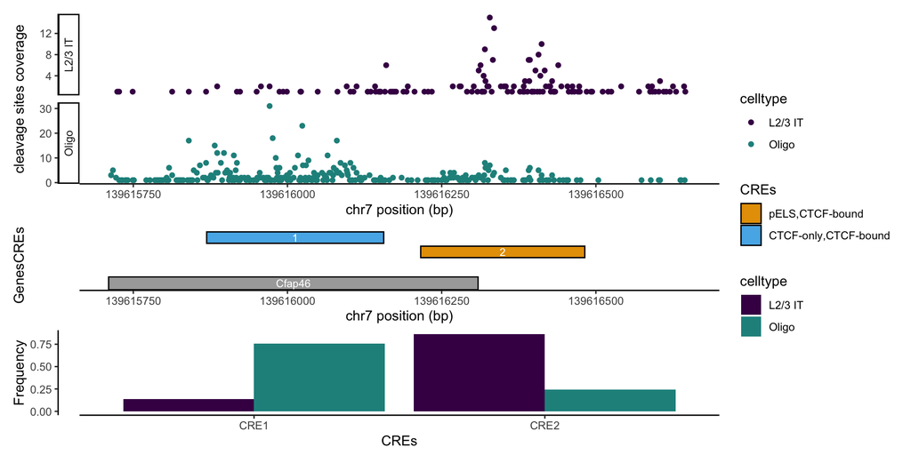

```r
Visualize(mouse_comparison1, which_peak = "chr7-139615710-139616653")
```

If you are interested in a specific peak, like the contribution of each CRE to the chi-square statistics, you can extract more details using the `Extract()` function.

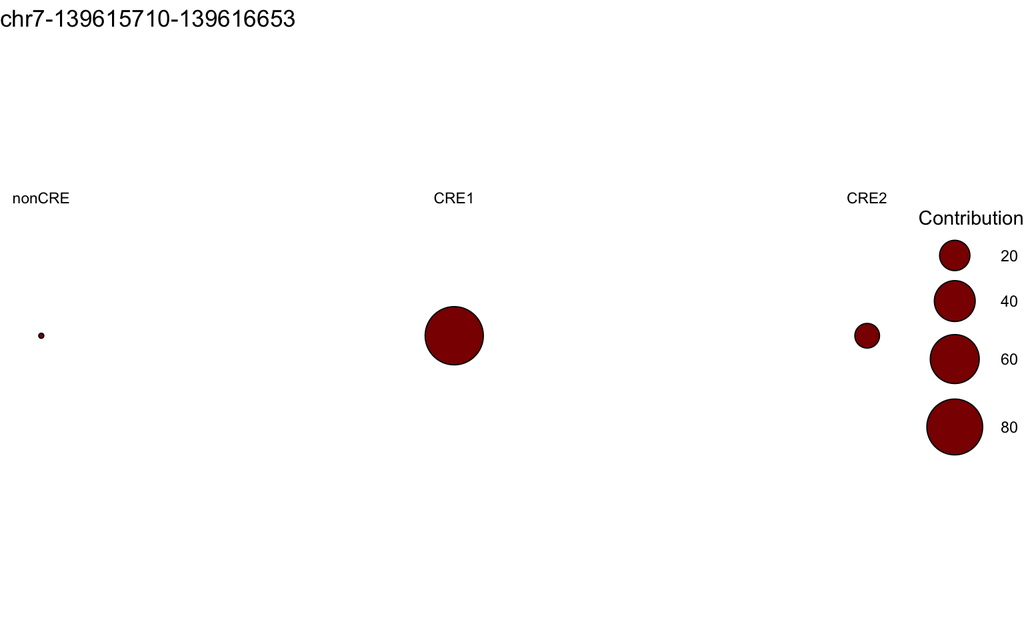

```r
info_for_a_peak <- Extract(mouse_comparison1, which_peak = "chr7-139615710-139616653")
info_for_a_peak$plot_contribution
```

```r
info_for_a_peak$annotation
```

```
##                          chisq_stat fdr max_contribution max_refID   max_dif
## chr7-139615710-139616653   2181.207   0         87.67617         1 0.8271871
##                            abs_dif n_1 n_2 df1
## chr7-139615710-139616653 0.5298824 271 754   3
##                                                      CRE_type seqnames
## chr7-139615710-139616653 pELS,CTCF-bound;CTCF-only,CTCF-bound     chr7
##                              start       end width strand annotation geneChr
## chr7-139615710-139616653 139615710 139616653   944      *   Promoter       7
##                          geneStart   geneEnd geneLength geneStrand geneId
## chr7-139615710-139616653 139601080 139616309      15230          2 212124
##                                   transcriptId distanceToTSS            ENSEMBL
## chr7-139615710-139616653 ENSMUST00000093991.10             0 ENSMUSG00000049571
##                          SYMBOL                                 GENENAME
## chr7-139615710-139616653 Cfap46 cilia and flagella associated protein 46
```

The following is a visualization of the CREscendo test results for a specific gene (Cfap46).

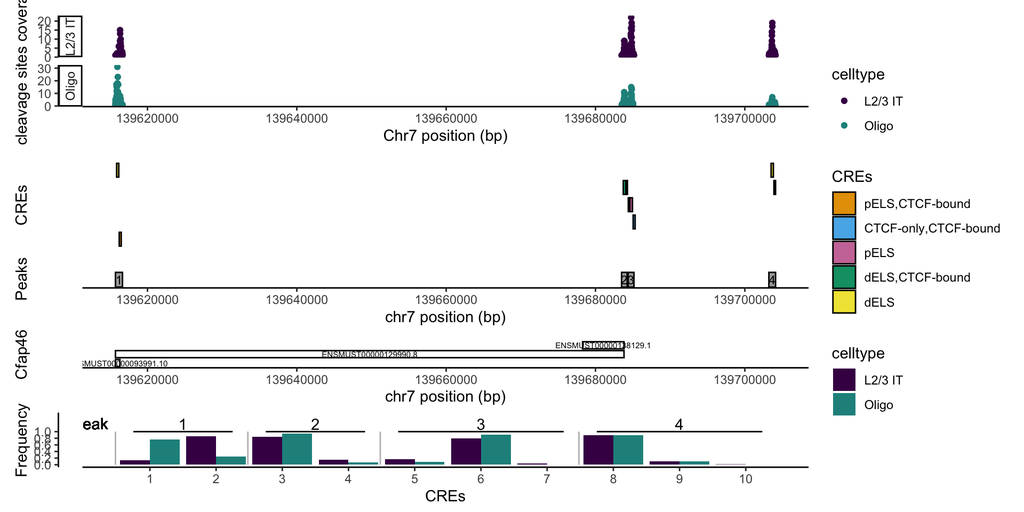

```r
Visualize(mouse_comparison1, which_gene = "Cfap46")
```

Similarly, more details can be extracted.

```r
info_for_a_gene <- Extract(mouse_comparison1, which_gene = "Cfap46")
info_for_a_gene$peak_annotation
```

```
##                            chisq_stat         fdr max_contribution max_refID
## chr7-139615710-139616653 2181.2069324 0.000000000         87.67617         1
## chr7-139683487-139684239   14.6993874 0.002154365         55.95928         1
## chr7-139684371-139685149   18.2825065 0.001356975         42.35845         1
## chr7-139703220-139704113    0.2972222 0.917037969         75.70093         2
##                            max_dif    abs_dif n_1 n_2 df1
## chr7-139615710-139616653 0.8271871 0.52988245 271 754   3
## chr7-139683487-139684239 0.5533333 0.11738806 268 200   3
## chr7-139684371-139685149 1.0000000 0.08682171 430 222   4
## chr7-139703220-139704113 1.0000000 0.01377410 242  84   4
##                                                      CRE_type seqnames
## chr7-139615710-139616653 pELS,CTCF-bound;CTCF-only,CTCF-bound     chr7
## chr7-139683487-139684239                            pELS;pELS     chr7
## chr7-139684371-139685149 dELS,CTCF-bound;dELS,CTCF-bound;dELS     chr7
## chr7-139703220-139704113            pELS,CTCF-bound;pELS;pELS     chr7
##                              start       end width strand        annotation
## chr7-139615710-139616653 139615710 139616653   944      *          Promoter
## chr7-139683487-139684239 139683487 139684239   753      *          Promoter
## chr7-139684371-139685149 139684371 139685149   779      *          Promoter
## chr7-139703220-139704113 139703220 139704113   894      * Distal Intergenic
##                          geneChr geneStart   geneEnd geneLength geneStrand
## chr7-139615710-139616653       7 139601080 139616309      15230          2
## chr7-139683487-139684239       7 139600951 139683817      82867          2
## chr7-139684371-139685149       7 139678270 139683817       5548          2
## chr7-139703220-139704113       7 139678270 139683817       5548          2
##                          geneId          transcriptId distanceToTSS
## chr7-139615710-139616653 212124 ENSMUST00000093991.10             0
## chr7-139683487-139684239 212124  ENSMUST00000129990.8             0
## chr7-139684371-139685149 212124  ENSMUST00000138129.1          -554
## chr7-139703220-139704113 212124  ENSMUST00000138129.1        -19403
##                                     ENSEMBL SYMBOL
## chr7-139615710-139616653 ENSMUSG00000049571 Cfap46
## chr7-139683487-139684239 ENSMUSG00000049571 Cfap46
## chr7-139684371-139685149 ENSMUSG00000049571 Cfap46
## chr7-139703220-139704113 ENSMUSG00000049571 Cfap46
##                                                          GENENAME
## chr7-139615710-139616653 cilia and flagella associated protein 46
## chr7-139683487-139684239 cilia and flagella associated protein 46
## chr7-139684371-139685149 cilia and flagella associated protein 46
## chr7-139703220-139704113 cilia and flagella associated protein 46
```

## Comparing with differential accessbility analysis

```r
DefaultAssay(brain) <- 'peaks'
tic()
da_peaks <- FindMarkers(
  object = brain,
  ident.1 = c("L2/3 IT"),
  ident.2 = c("Oligo"),
  test.use = 'LR',
  latent.vars = 'nCount_peaks'
)
toc()
```

```
## 1865.558 sec elapsed
```

We further compared the results from CREscendo and DA tests.

```r
chisq_test_summary <- Summarize(mouse_comparison1)
commons <- intersect(rownames(chisq_test_summary), rownames(da_peaks))
all_stats <- cbind(chisq_test_summary[commons, ], da_peaks[commons, ])


# Updated ggplot2 code with ggrepel for non-overlapping text labels
dq <- ggplot(all_stats, aes(x = avg_log2FC, y = chisq_stat)) +
  geom_point( size = 0.8) +
  geom_text_repel(data = subset(all_stats, chisq_stat > 2000),
                  aes(label = SYMBOL),
                  max.overlaps = Inf,
                  box.padding = 0.5,
                  point.padding = 0.5,
                  size = 3,  color = 'darkred') +
  xlim(-6, 6) +  # Slightly wider x-axis limits
  ylim(min(all_stats$chisq_stat), max(all_stats$chisq_stat) + 500) +  # Extend y-axis if necessary
  theme_classic() + labs(title = "L2/3 IT vs. Oligo", x = "Avg log2FC", y = "Chi-square statistics") +
  theme(plot.margin = margin(1, 1, 1, 1, "cm"))  # Set x-axis limits
```

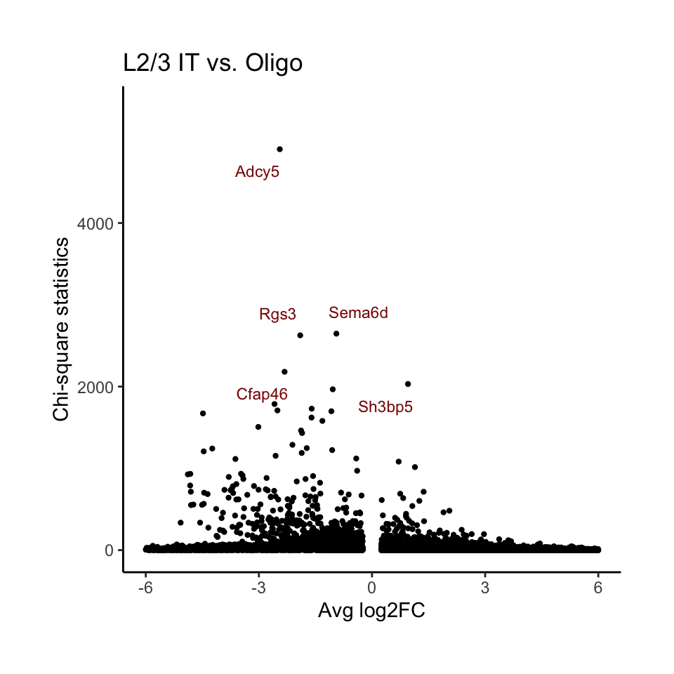

```r
dq
```